# MTH6139 Time Series

Inflation and its effects”Coursework 1”

Hassan Mohamed

Spring term 2025

# Introduction

I chose to explore the UK inflation rate over a ten-year period.

The reason I chose this topic is because inflation has a direct effect on everyday life for the general public, including the rising cost of groceries and other essentials. I am also interested in how inflation can be influenced by a range of different economic factors.

The aim of this project is to explore how inflation has changed over time and to use Meta’s Prophet model to forecast future values.

And understanding inflation trends is important for both consumers and businesses, as it influences spending decisions and overall economic activity.

# Getting the Data Ready

The dataset is stored as a CSV file within the project folder. It is first loaded into R so that its structure and contents can be checked before any analysis is carried out.

```r
cpi_data <- read.csv("data/GBRCPIALLMINMEI.csv")

head(cpi_data)
```

```
##   observation_date GBRCPIALLMINMEI
## 1       2015-03-01            99.6
## 2       2015-04-01            99.9
## 3       2015-05-01           100.1
## 4       2015-06-01           100.1
## 5       2015-07-01           100.0
## 6       2015-08-01           100.3
```

```r
str(cpi_data)
```

```
## 'data.frame':    121 obs. of  2 variables:
##  $ observation_date: chr  "2015-03-01" "2015-04-01" "2015-05-01" "2015-06-01" ...
##  $ GBRCPIALLMINMEI : num  99.6 99.9 100.1 100.1 100 ...
```

```r
names(cpi_data)
```

```
## [1] "observation_date" "GBRCPIALLMINMEI"
```

The dataset has multiple years worth of data, which makes it suitable for identifying long-term trends and building a forecasting model.

From this, you can see that the dataset contains a date column and a numerical column representing the CPI index. Some formatting adjustments are required to make the data compatible with Prophet.

# Cleaning and format data

The dataset is then cleaned and converted into the format required by Prophet, with `ds` representing dates and `y` representing values.

```r
cpi_data$ds <- as.Date(cpi_data$observation_date)
cpi_data$y <- cpi_data$GBRCPIALLMINMEI

cpi_data <- cpi_data[, c("ds", "y")]

head(cpi_data)
```

```
##           ds     y
## 1 2015-03-01  99.6
## 2 2015-04-01  99.9
## 3 2015-05-01 100.1
## 4 2015-06-01 100.1
## 5 2015-07-01 100.0
## 6 2015-08-01 100.3
```

The original column names are adjusted to match the format required by Prophet. The date column is converted into a standard date format, and the CPI values are stored in a single numerical column.

# Exploring the Data

Before building a forecasting model, it is important to understand how inflation has behaved over time.

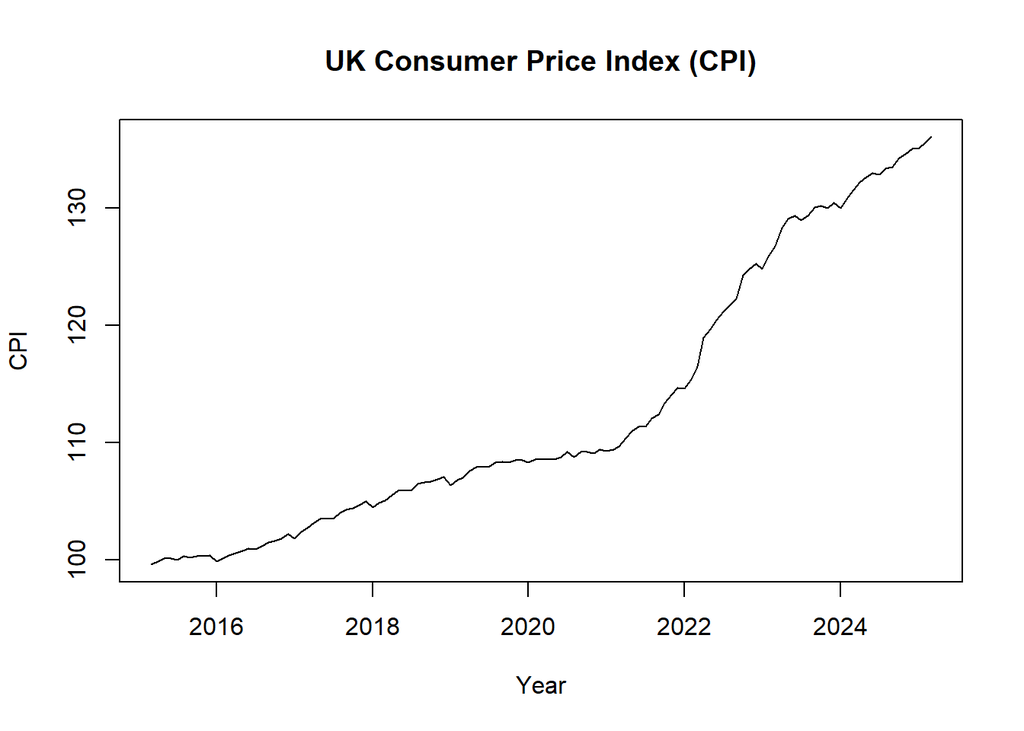

```r
plot(cpi_data$ds, cpi_data$y, type = "l",
     main = "UK Consumer Price Index (CPI)",
     xlab = "Year", ylab = "CPI")
```

The plot shows a clear upward trend over time, indicating that prices have generally increased. There are also periods where inflation rises more sharply, reflecting economic shocks or changes in monetary conditions.

CPI is set to 100 in a base year, and the difference from 100 shows the percentage change in prices since that year, while inflation is measured by the percentage change between consecutive CPI values.

To better understand the distribution of CPI values, a histogram is also considered.

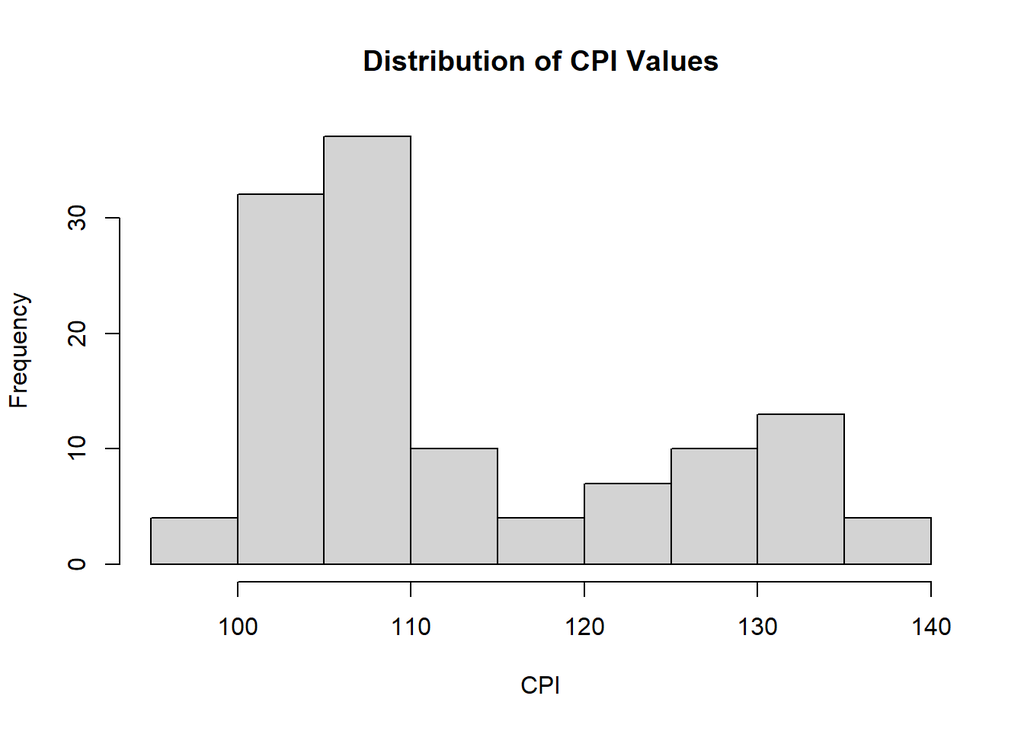

```r
hist(cpi_data$y,
     main = "Distribution of CPI Values",
     xlab = "CPI")
```

The distribution is right-skewed, reflecting the long-term increase in price levels over time.

# Forecasting with Prophet

To model the time series, Meta’s Prophet forecasting tool is used. This model is well suited for capturing trends and potential seasonal effects.Prophet decomposes the time series into different components, including trend and seasonality, allowing it to model complex patterns in the data.

The model is fitted using the prepared dataset.

```r
library(prophet)

cpi_model <- prophet(cpi_data)
```

The model identifies the overall trend in inflation and uses this to form the basis of future predictions.

# Producing the Forecast

Once the model has been fitted, future dates are generated in order to extend the time series.

```r
future_dates <- make_future_dataframe(cpi_model, periods = 24, freq = "month")
forecast <- predict(cpi_model, future_dates)
```

This allows the model to forecast inflation over the next two years.The forecast is based on the assumption that past patterns in the data will continue into the future.

# Forecast Results

The forecast can be visualised alongside the historical data.

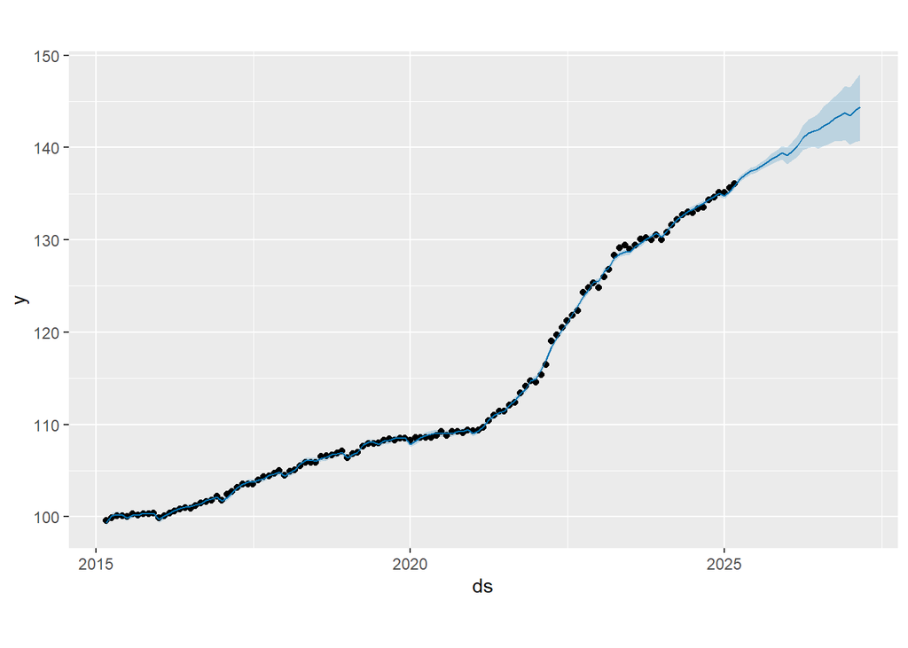

```r
plot(cpi_model, forecast)
```

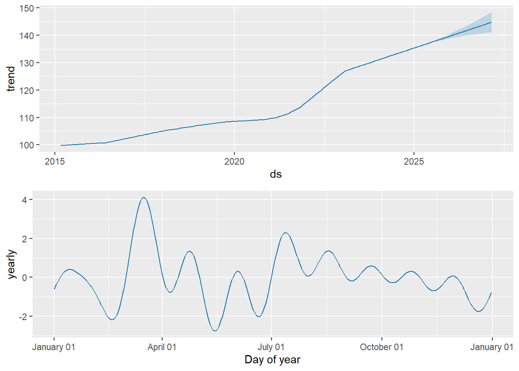

```r
prophet::prophet_plot_components(cpi_model, forecast)
```

The components plot highlights the dominance of the trend component, with limited seasonal influence. This supports the earlier observation that inflation is primarily trend-driven.

# Conclusion

In this project, UK inflation data was analysed using the Consumer Price Index. The data showed a strong long-term upward trend, reflecting rising price levels over time.

Using Prophet, a forecasting model was developed which successfully captured this trend and produced reasonable future projections. The results suggest that inflation is largely driven by long-term economic factors rather than strong seasonal patterns.

Overall, this project demonstrates how time series models can be used to gain insight into important economic indicators and support data-driven decision making.

# Reference

*Prophet: Forecasting at scale*

*Forecasting: Principles and Practice*

*Time Series Analysis: Forecasting and Control*.

*https://fred.stlouisfed.org/series/GBRCPIALLMINMEI*